# PML Prediction Assignment

## Pre-processing

We first load the data from the csv files into R.

```r
training = read.csv("/pml/pml-training.csv", head=TRUE)
```

The prediction variable is a category of 5 possible values.

```r
summary(training$classe)
```

```
##    A    B    C    D    E
## 5580 3797 3422 3216 3607
```

The data contains a large number of invalid values like “#DIV/0!” and NA. We set “#DIV/0!” to NA and remove all columns with NA values. The number of factors is now 60 from 160 we started with.

```r
t1 = training;
t1[t1 == "#DIV/0!"] = NA
t2 = t1[, colSums(is.na(t1)) == 0 ]
names(t2)
```

```
##  [1] "X"                    "user_name"            "raw_timestamp_part_1"
##  [4] "raw_timestamp_part_2" "cvtd_timestamp"       "new_window"
##  [7] "num_window"           "roll_belt"            "pitch_belt"
## [10] "yaw_belt"             "total_accel_belt"     "gyros_belt_x"
## [13] "gyros_belt_y"         "gyros_belt_z"         "accel_belt_x"
## [16] "accel_belt_y"         "accel_belt_z"         "magnet_belt_x"
## [19] "magnet_belt_y"        "magnet_belt_z"        "roll_arm"
## [22] "pitch_arm"            "yaw_arm"              "total_accel_arm"
## [25] "gyros_arm_x"          "gyros_arm_y"          "gyros_arm_z"
## [28] "accel_arm_x"          "accel_arm_y"          "accel_arm_z"
## [31] "magnet_arm_x"         "magnet_arm_y"         "magnet_arm_z"
## [34] "roll_dumbbell"        "pitch_dumbbell"       "yaw_dumbbell"
## [37] "total_accel_dumbbell" "gyros_dumbbell_x"     "gyros_dumbbell_y"
## [40] "gyros_dumbbell_z"     "accel_dumbbell_x"     "accel_dumbbell_y"
## [43] "accel_dumbbell_z"     "magnet_dumbbell_x"    "magnet_dumbbell_y"
## [46] "magnet_dumbbell_z"    "roll_forearm"         "pitch_forearm"
## [49] "yaw_forearm"          "total_accel_forearm"  "gyros_forearm_x"
## [52] "gyros_forearm_y"      "gyros_forearm_z"      "accel_forearm_x"
## [55] "accel_forearm_y"      "accel_forearm_z"      "magnet_forearm_x"
## [58] "magnet_forearm_y"     "magnet_forearm_z"     "classe"
```

Note that there is an **X** variable which counts the index and our category of classe is sorted. Additionally, as seen in the graph below, users move from classe A to E with time and so timestamps and related variables should be removed from the training.

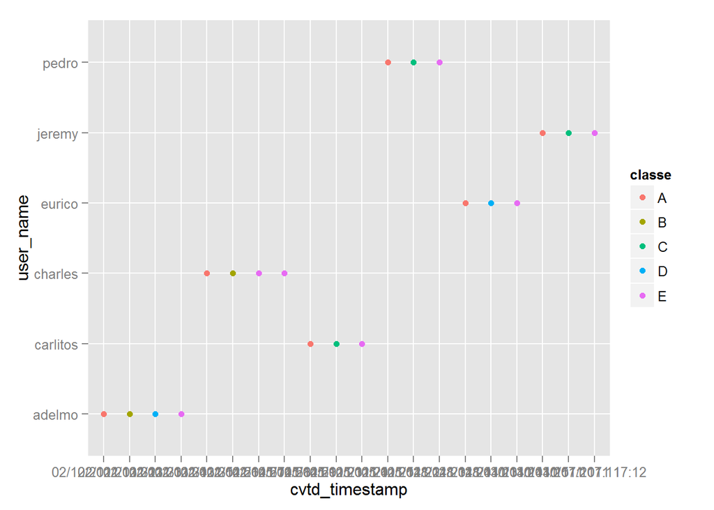

```r
t3 = t2[,-c(1:7)]
qplot( cvtd_timestamp, user_name, color=classe, data=t2)
```

## Training

Our problem is of classification we will use random forests classification algorithm. However, we have ~20,000 observations which is too large for the computer to handle. So, we work with only a fraction of the observations.

We randomly sample 10% observations and then build a random forest from it.

```r
set.seed(12345)
dp1 = createDataPartition(y=t3$classe, p=0.1, list=FALSE)
t3_1 = t3[dp1,]
rfModel = randomForest(classe~., data=t3_1, importance=TRUE, proximity=TRUE)
```

The most important factors are *roll_belt* and *magnet_dumbbell_z* and from the plot below, we can see that there is some separation of the classes from the factors.

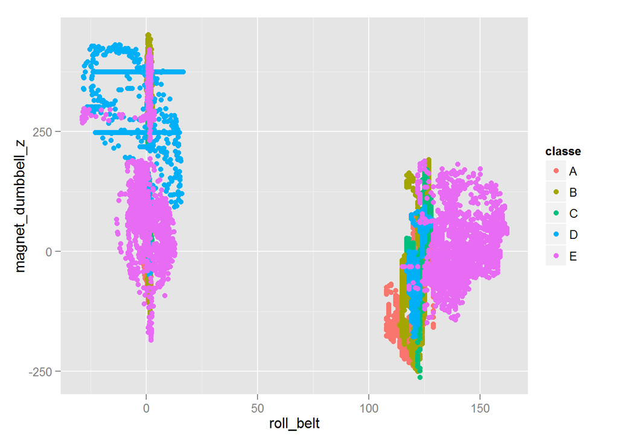

```r
qplot(roll_belt, magnet_dumbbell_z, color=classe, data=t3)
```

## Predicting Out of Sample Errors

Since we only used 10% of the data for our model training, we can use the rest of the 90% to do our testing.

```r
ts3_1 = t3[-dp1,]
confusionMatrix(predict(rfModel, ts3_1), ts3_1$classe)
```

```
## Confusion Matrix and Statistics
##
##           Reference
## Prediction    A    B    C    D    E
##          A 4966  119    0   16    2
##          B    6 3137  106    2   59
##          C   24  155 2960  172   70
##          D    9    6   12 2689   16
##          E   17    0    1   15 3099
##
## Overall Statistics
##
##                Accuracy : 0.9543
##                  95% CI : (0.9511, 0.9573)
##     No Information Rate : 0.2844
##     P-Value [Acc > NIR] : < 2.2e-16
##
##                   Kappa : 0.9422
##  Mcnemar's Test P-Value : < 2.2e-16
##
## Statistics by Class:
##
##                      Class: A Class: B Class: C Class: D Class: E
## Sensitivity            0.9888   0.9181   0.9614   0.9292   0.9547
## Specificity            0.9892   0.9879   0.9711   0.9971   0.9977
## Pos Pred Value         0.9732   0.9477   0.8755   0.9843   0.9895
## Neg Pred Value         0.9955   0.9805   0.9917   0.9863   0.9899
## Prevalence             0.2844   0.1935   0.1744   0.1639   0.1838
## Detection Rate         0.2812   0.1777   0.1676   0.1523   0.1755
## Detection Prevalence   0.2890   0.1875   0.1915   0.1547   0.1774
## Balanced Accuracy      0.9890   0.9530   0.9662   0.9631   0.9762
```

We get 95% accuracy with our results. We can choose another seed and again find the out of the sample error and all of them come around 95% accuracy.

```r
set.seed(54321)
dp2 = createDataPartition(y=t3$classe, p=0.1, list=FALSE)
t3_2 = t3[dp2,]
rfModel = randomForest(classe~., data=t3_2, importance=TRUE, proximity=TRUE)
ts3_2 = t3[-dp2,]
confusionMatrix(predict(rfModel, ts3_2), ts3_2$classe)
```

```
## Confusion Matrix and Statistics
##
##           Reference
## Prediction    A    B    C    D    E
##          A 4971  182   21   24    3
##          B   32 3160  126   12   17
##          C    6   68 2885  191   43
##          D    6    0   47 2659   37
##          E    7    7    0    8 3146
##
## Overall Statistics
##
##                Accuracy : 0.9526
##                  95% CI : (0.9494, 0.9557)
##     No Information Rate : 0.2844
##     P-Value [Acc > NIR] : < 2.2e-16
##
##                   Kappa : 0.94
##  Mcnemar's Test P-Value : < 2.2e-16
##
## Statistics by Class:
##
##                      Class: A Class: B Class: C Class: D Class: E
## Sensitivity            0.9898   0.9248   0.9370   0.9188   0.9692
## Specificity            0.9818   0.9869   0.9789   0.9939   0.9985
## Pos Pred Value         0.9558   0.9441   0.9035   0.9673   0.9931
## Neg Pred Value         0.9959   0.9820   0.9866   0.9842   0.9931
## Prevalence             0.2844   0.1935   0.1744   0.1639   0.1838
## Detection Rate         0.2815   0.1790   0.1634   0.1506   0.1782
## Detection Prevalence   0.2945   0.1895   0.1808   0.1557   0.1794
## Balanced Accuracy      0.9858   0.9558   0.9579   0.9564   0.9838
```

When we double our sample to 20%, we get 97% accuracy but the processing time is much more than double.

```r
set.seed(32123)
dp3 = createDataPartition(y=t3$classe, p=0.2, list=FALSE)
t3_3 = t3[dp3,]
rfModel = randomForest(classe~., data=t3_3, importance=TRUE, proximity=TRUE)
ts3_3 = t3[-dp3,]
confusionMatrix(predict(rfModel, ts3_3), ts3_3$classe)
```

```
## Confusion Matrix and Statistics
##
##           Reference
## Prediction    A    B    C    D    E
##          A 4441   73    1    7    0
##          B   11 2906   81    0    7
##          C    9   57 2615  132    5
##          D    2    1   39 2424   17
##          E    1    0    1    9 2856
##
## Overall Statistics
##
##                Accuracy : 0.9711
##                  95% CI : (0.9684, 0.9737)
##     No Information Rate : 0.2844
##     P-Value [Acc > NIR] : < 2.2e-16
##
##                   Kappa : 0.9635
##  Mcnemar's Test P-Value : < 2.2e-16
##
## Statistics by Class:
##
##                      Class: A Class: B Class: C Class: D Class: E
## Sensitivity            0.9948   0.9569   0.9554   0.9425   0.9899
## Specificity            0.9928   0.9922   0.9843   0.9955   0.9991
## Pos Pred Value         0.9821   0.9671   0.9280   0.9762   0.9962
## Neg Pred Value         0.9979   0.9897   0.9905   0.9888   0.9977
## Prevalence             0.2844   0.1935   0.1744   0.1639   0.1838
## Detection Rate         0.2830   0.1852   0.1666   0.1544   0.1820
## Detection Prevalence   0.2881   0.1915   0.1795   0.1582   0.1827
## Balanced Accuracy      0.9938   0.9745   0.9699   0.9690   0.9945
```